# xv20220829_S8_BRCA2_tumors

x.vergara

2022-09-28

#Intro: This figure corresponds to figure S8 in the main text.

Fig. S8: BRCA2+/+ and BRCA2-/- mutation analysis. (A) log2 fold change of the five indel signatures called per tumor in BRCA2-/- compared to BRCA2+/+. (B) Total NHEJ and MMEJ counts on BRCA2+/+ tumors (n = 22) in euchromatin (Eu.) and constitutive lamina-associated heterochromatin (Het.). A Fisher’s count exact test was run on these values to test for differential accumulation of MMEJ and NHEJ deletions in Eu. and Het. (C) Total NHEJ and MMEJ counts on BRCA2-/- tumors (n = 41) in Eu. and Het. (D) Total number of large deletions with MH at break sites in euchromatin (Eu.) and constitutive lamina-associated heterochromatin (Het.) in BRCA2+/+ and BRCA2-/-.

#Script set-up

```r
knitr::opts_chunk$set(root.dir = '/home/x.vergara/XV_P3_ChromDSBScreen/xv_CRISPR_screen_figures/rmarkdown/xv20210920_paper_scripts/short_version/knit_html/')

StartTime <-Sys.time()
library(knitr)

# 8-digit Date tag:
Date <- substr(gsub("-","",Sys.time()),1,8)

#Change in.dir accordingly
in.dir <- "/home/x.vergara/XV_P3_ChromDSBScreen/xv_CRISPR_screen_figures/"

#Check if output contain datetag
saveRDS_proof <- function(object, file) {
  document_path <- rstudioapi::getSourceEditorContext()$path %>% str_split(pattern = "/") %>% unlist()
  document_name <- document_path[length(document_path)]
  sys_time <- Sys.time()
  if (grepl(Date, file) == T) {
    saveRDS(object, file)
    #write(c(document_name, as.character(sys_time),"Output", correct_file), file = paste0(in.dir,"log"), ncolumns = 4, sep = "\t", append = T)
  }
  else {
    print("Incorrect datetag!")
  }
}

#Read rds check through different versions
readRDS_proof <- function(path, pat) {
  full.path <- paste0(in.dir, path)
  document_path <- rstudioapi::getSourceEditorContext()$path %>% str_split(pattern = "/") %>% unlist()
  document_name <- document_path[length(document_path)]
  sys_time <- Sys.time()

  if(file.exists(full.path) == T){
    if(paste0(in.dir,path) != getwd()){
      setwd(paste0(in.dir, path))
  }
    file.list <- list.files(pattern = pat)
    correct_file <- str_sort(file.list, decreasing = T)[1]
    print(correct_file)
    base::readRDS(file = correct_file)
    #write(c(document_name,as.character(sys_time) ,"Input", correct_file), file = paste0(in.dir,"log"), ncolumns = 4, sep = "\t", append = T)

  }
  else{
  setwd(path)
  file.list <- list.files(pattern = pat)
  correct_file <- str_sort(file.list, decreasing = T)[1]
  print(correct_file)
  base::readRDS(file = correct_file)
  #write(c(document_name, as.character(sys_time),"Input", correct_file),file = paste0(in.dir,"log"), ncolumns = 4, sep = "\t", append = T)
  }
}
```

# Libraries

```r
# setwd
setwd(in.dir)

# libraries:
library(tidyverse)
library(reshape2)
library(broom)
library(ggrepel)
library(dendextend)
library(umap)
library(igraph)
library(lsa)
library(tibble)
library(utils)
library(base)
library(scales)
library(openxlsx)
```

# Input files for this script: Data needed for figure 4 and come from the processed_data directory

```r
# setwd
setwd(in.dir)

#Print note:
print(paste("The following datasets will be loaded for this script:"))
```

```
## [1] "The following datasets will be loaded for this script:"
```

```r
#Tumor analysis
SV_MH_del_data_tumors <- readRDS_proof("data/processed_data/","SCC_SV_MH_deletions")
```

```
## [1] "xv20220920_SCC_SV_MH_deletions.rds"
```

```r
indel_data_tumors <- readRDS_proof("data/processed_data/","SCC_indel_MMEJ_NHEJ")
```

```
## [1] "xv20220922_SCC_indel_MMEJ_NHEJ_deletions.rds"
```

```r
HPVneg_HNSCC_export_indel <- read.xlsx(paste0(in.dir,"data/supplementary_tables/xv20220922_Table_S10a_indel_mutations_tumors_COSMIC.xlsx"))
BRCA2_HNSCC_export_indel <-  read.xlsx(paste0(in.dir,"data/supplementary_tables/xv20220922_Table_S10b_indel_mutations_tumors_COSMIC.xlsx"))
```

#Preparatory chunk: Prepare BRCA2-/- data for plotting and compute statistics

```r
#Quick check of mutation accumulation
#Check indels and see how they look quickly (HNSC)
summary_table_HNSCC <- HPVneg_HNSCC_export_indel %>% dplyr::group_by(CLASS) %>% dplyr::summarise(total_numbers = n()/22,
                                                                                     tumortype = "HNSC")

#Check indels and see how they look quickly (HNSC)
summary_table_BRCA2 <- BRCA2_HNSCC_export_indel %>% dplyr::group_by(CLASS) %>% dplyr::summarise(total_numbers = n()/41,
                                                                                     tumortype = "BRCA2")

## Merge
summary_table <- bind_rows(summary_table_BRCA2, summary_table_HNSCC) %>%
  reshape2::dcast(CLASS ~ tumortype, value.var = "total_numbers") %>%
  mutate(fold_change = BRCA2/HNSC)

# SV data
distribution_tumor <- SV_MH_del_data_tumors %>%
  filter(ciLAD == 1 | cLAD == 1) %>%
  mutate(LAD_status = case_when(ciLAD == 1 ~ "ciLAD",
                                cLAD == 1 ~ "cLAD")) %>%
  dplyr::group_by(type, tumor_id, LAD_status, total_MH_del) %>% dplyr::summarise(mut_count = n(), .groups = "drop") %>%
  reshape2::dcast(type + tumor_id + total_MH_del ~ LAD_status, value.var = "mut_count", fill = 0) %>%
  dplyr::group_by(type) %>%
  dplyr::summarise(freq_ciLAD = sum(ciLAD,na.rm = T)/sum(total_MH_del, na.rm = T),
                   freq_cLAD = sum(cLAD,na.rm = T)/sum(total_MH_del, na.rm = T),
                   log2_ratio = log2(sum(cLAD, na.rm = T)/sum(ciLAD, na.rm = T)),
                  tot_cLAD = sum(cLAD),
                   tot_ciLAD = sum(ciLAD))


#Indel data
distribution_tumor_indel <- indel_data_tumors %>%
  filter(ciLAD == 1 | cLAD == 1) %>%
  mutate(LAD_status = case_when(ciLAD == 1 ~ "ciLAD",
                                cLAD == 1 ~ "cLAD")) %>%
  dplyr::group_by(tumor_type, tumor_id, LAD_status, total_mutation, CLASS) %>% dplyr::summarise(mut_count = n(), .groups = "drop") %>%
  reshape2::dcast(tumor_type + tumor_id + total_mutation + CLASS ~ LAD_status, value.var = "mut_count", fill = 0) %>%
dplyr::group_by(tumor_type, CLASS) %>%
  dplyr::summarise(freq_ciLAD = sum(ciLAD,na.rm = T)/sum(total_mutation, na.rm = T),
                   freq_cLAD = sum(cLAD,na.rm = T)/sum(total_mutation, na.rm = T),
                   log2_ratio = log2(sum(cLAD, na.rm = T)/sum(ciLAD, na.rm = T)),
                   tot_cLAD = sum(cLAD),
                   tot_ciLAD = sum(ciLAD))
```

#Figure S8A: (A) log2 fold change of the five indel signatures called per tumor in BRCA2-/- compared to BRCA2+/+.

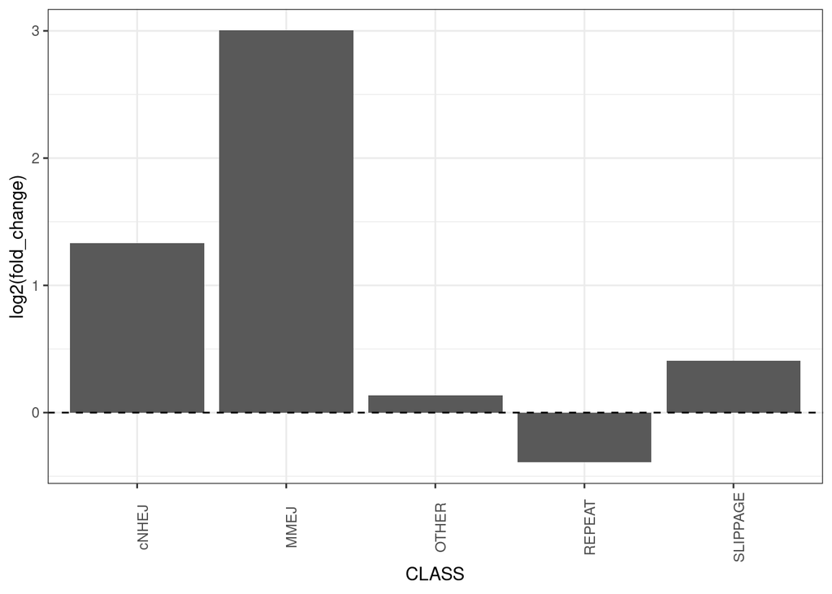

```r
#
ggplot(summary_table) + geom_col(aes(CLASS, log2(fold_change))) + theme_bw() +
  theme(axis.text.x = element_text(angle = 90, hjust = 0.5)) + geom_hline(yintercept = 0, linetype = 2)
```

#Figure S8B: (B) Total NHEJ and MMEJ counts on BRCA2+/+ tumors (n = 22) in euchromatin (Eu.) and constitutive lamina-associated heterochromatin (Het.).

[figure not shown]

```r
# Data for plotting
plot_data_bars_test <- distribution_tumor_indel %>% select(-freq_ciLAD,-freq_cLAD, -log2_ratio) %>% reshape2::melt()

#Plot HNSC S8B
ggplot(plot_data_bars_test %>% filter(tumor_type == "HHNSC_indel")) + geom_col(aes(fct_relevel(variable, c("tot_ciLAD","tot_cLAD")),value)) + facet_wrap(~fct_relevel(CLASS, c("cNHEJ","MMEJ")), ncol = 1, scales = "free") + theme_bw()
```

#Figure S8C (C) Total NHEJ and MMEJ counts on BRCA2-/- tumors (n = 41) in Eu. and Het.

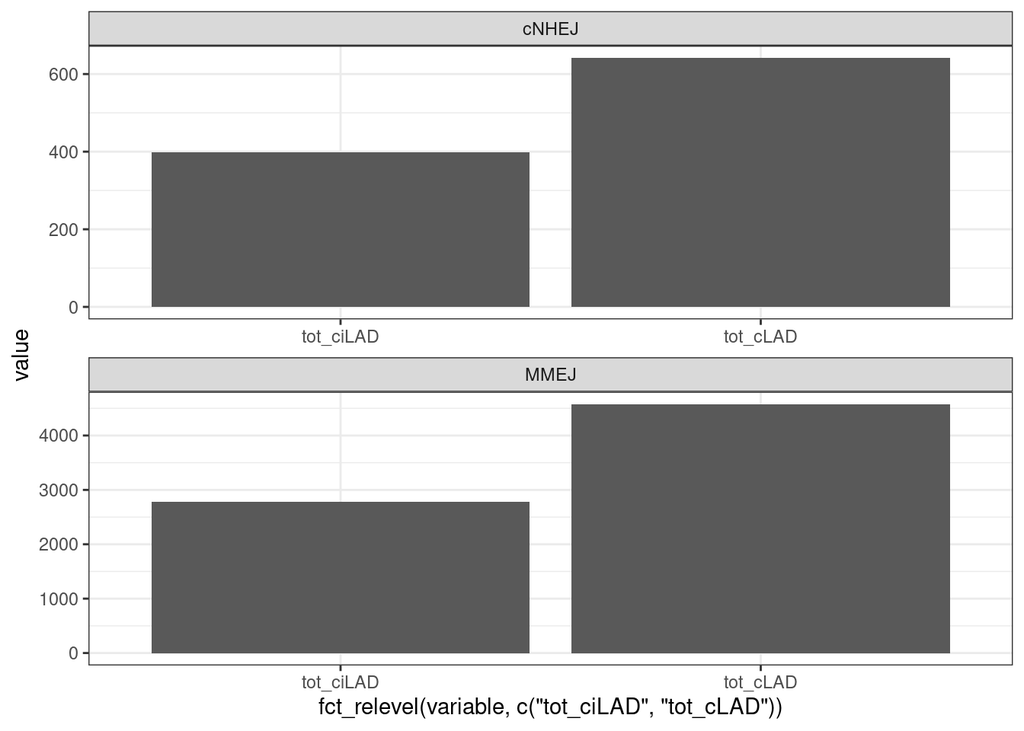

```r
#Plot BRCA2 S8C
ggplot(plot_data_bars_test %>% filter(tumor_type == "BRCA2mut_indel")) + geom_col(aes(fct_relevel(variable, c("tot_ciLAD","tot_cLAD")),value)) + facet_wrap(~fct_relevel(CLASS, c("cNHEJ","MMEJ")), ncol = 1, scales = "free") + theme_bw()
```

#Figure S8D (D) Total number of large deletions with MH at break sites in euchromatin (Eu.) and constitutive lamina-associated heterochromatin (Het.) in BRCA2+/+ and BRCA2-/-.

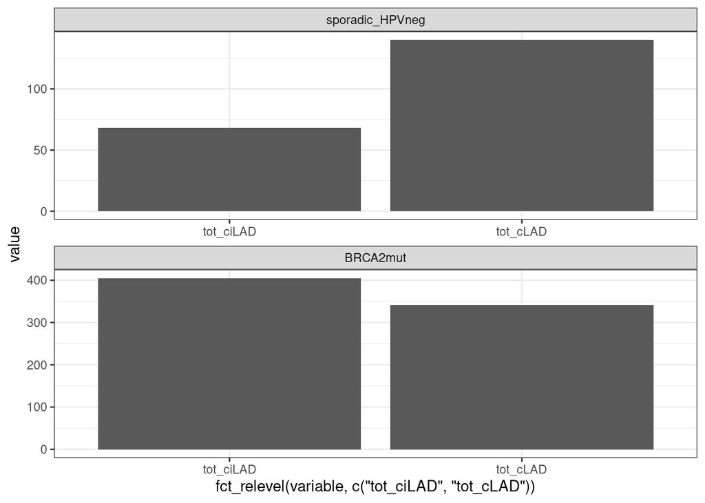

```r
#Plot SV S8D
plot_SV_data <- distribution_tumor %>% select(-freq_ciLAD,-freq_cLAD, -log2_ratio) %>% reshape2::melt()

ggplot(plot_SV_data) + geom_col(aes(fct_relevel(variable, c("tot_ciLAD","tot_cLAD")),value)) + facet_wrap(~fct_relevel(type, c("sporadic_HPVneg","BRCA2mut")), ncol = 1, scales = "free") + theme_bw()
```

```r
SV_fisher <- distribution_tumor %>% ungroup() %>% select(-freq_ciLAD, -freq_cLAD, -log2_ratio) %>% column_to_rownames(var = "type") %>% fisher.test() %>% tidy()

print(SV_fisher)
```

```
## # A tibble: 1 × 6
##   estimate      p.value conf.low conf.high method                        alter…¹
##      <dbl>        <dbl>    <dbl>     <dbl> <chr>                         <chr>
## 1    0.411 0.0000000348    0.292     0.573 Fisher's Exact Test for Coun… two.si…
## # … with abbreviated variable name ¹alternative
```